# Housing Price Model - Data Preprocessing

Author: **Paul A. Beata**  
GitHub: pbeata

*The original data set comes from the [Ames, Iowa housing data](https://www.kaggle.com/marcopale/housing) on Kaggle.*

**Description of the columns (features):** Each column represents a different feature of the home. Some of the features are numerical (such as "lot area" and "year built) and others are categorical (e.g., "neighboorhood" and "Building Type"). There are some features with absolute measurements, such as areas or distances, but there are also subjective ones like overall quality at the time of sale. A description each feature is provided in the "Ames_Housing_Data_Feature_Description.txt" file included with this project and referenced in this notebook.

**Description of the targets:** The target is the sale price of the house. Our ultimate goal is to build regression models to predict the sale price of a home based on its features. In this notebook, we will only focus on the data preprocessing.

**Description of the rows:** Each row of the data set is a single observation (i.e., a single house). Each house is identified in the "PID" column which is a unique identifier for each property.

**Summary of data preprocessing performed in this notebook:** Since this data set has missing values and outliers, we will first perform the following data preprocessing steps before building the regression models in a separate notebook.

1. Identify the potential outliers in the data set
2. Handle missing data using row-wise and/or column-wise solutions as appropriate
3. Create data checkpoints throughout the preprocessing
4. Handle the categorical data by making dummy variables
5. Save the final (cleaned) data set at the end of the notebook

## Part 0: Load the Original Data

```python
import numpy as np
import pandas as pd
import matplotlib.pyplot as plt
import seaborn as sns
%config Completer.use_jedi = False
```

Here we can see a detailed description of the features (columns) in the data set before we begin preprocessing:

```python
with open('./data_original/Ames_Housing_Data_Feature_Description.txt', 'r') as f:
    print(f.read())
```

```
MSSubClass: Identifies the type of dwelling involved in the sale.

        20	1-STORY 1946 & NEWER ALL STYLES
        30	1-STORY 1945 & OLDER
        40	1-STORY W/FINISHED ATTIC ALL AGES
        45	1-1/2 STORY - UNFINISHED ALL AGES
        50	1-1/2 STORY FINISHED ALL AGES
        60	2-STORY 1946 & NEWER
        70	2-STORY 1945 & OLDER
        75	2-1/2 STORY ALL AGES
        80	SPLIT OR MULTI-LEVEL
        85	SPLIT FOYER
        90	DUPLEX - ALL STYLES AND AGES
       120	1-STORY PUD (Planned Unit Development) - 1946 & NEWER
       150	1-1/2 STORY PUD - ALL AGES
       160	2-STORY PUD - 1946 & NEWER
       180	PUD - MULTILEVEL - INCL SPLIT LEV/FOYER
       190	2 FAMILY CONVERSION - ALL STYLES AND AGES

MSZoning: Identifies the general zoning classification of the sale.

       A	Agriculture
       C	Commercial
       FV	Floating Village Residential
       I	Industrial
       RH	Residential High Density
       RL	Residential Low Density
       RP	Residential Low Density Park
       RM	Residential Medium Density

LotFrontage: Linear feet of street connected to property

LotArea: Lot size in square feet

Street: Type of road access to property

       Grvl	Gravel
       Pave	Paved

Alley: Type of alley access to property
```

[output cut: 468 more lines]

```
       COD	Court Officer Deed/Estate
       Con	Contract 15% Down payment regular terms
       ConLw	Contract Low Down payment and low interest
       ConLI	Contract Low Interest
       ConLD	Contract Low Down
       Oth	Other

SaleCondition: Condition of sale

       Normal	Normal Sale
       Abnorml	Abnormal Sale -  trade, foreclosure, short sale
       AdjLand	Adjoining Land Purchase
       Alloca	Allocation - two linked properties with separate deeds, typically condo with a garage unit
       Family	Sale between family members
       Partial	Home was not completed when last assessed (associated with New Homes)
```

```python
# load the original raw data set
df = pd.read_csv('./data_original/Ames_Housing_Data.csv')
df
```

|  | PID | MS SubClass | MS Zoning | Lot Frontage | Lot Area | Street | Alley | Lot Shape | Land Contour | Utilities | ... | Pool Area | Pool QC | Fence | Misc Feature | Misc Val | Mo Sold | Yr Sold | Sale Type | Sale Condition | SalePrice |
| --- | --- | --- | --- | --- | --- | --- | --- | --- | --- | --- | --- | --- | --- | --- | --- | --- | --- | --- | --- | --- | --- |
| 0 | 526301100 | 20 | RL | 141.0 | 31770 | Pave | NaN | IR1 | Lvl | AllPub | ... | 0 | NaN | NaN | NaN | 0 | 5 | 2010 | WD | Normal | 215000 |
| 1 | 526350040 | 20 | RH | 80.0 | 11622 | Pave | NaN | Reg | Lvl | AllPub | ... | 0 | NaN | MnPrv | NaN | 0 | 6 | 2010 | WD | Normal | 105000 |
| 2 | 526351010 | 20 | RL | 81.0 | 14267 | Pave | NaN | IR1 | Lvl | AllPub | ... | 0 | NaN | NaN | Gar2 | 12500 | 6 | 2010 | WD | Normal | 172000 |
| 3 | 526353030 | 20 | RL | 93.0 | 11160 | Pave | NaN | Reg | Lvl | AllPub | ... | 0 | NaN | NaN | NaN | 0 | 4 | 2010 | WD | Normal | 244000 |
| 4 | 527105010 | 60 | RL | 74.0 | 13830 | Pave | NaN | IR1 | Lvl | AllPub | ... | 0 | NaN | MnPrv | NaN | 0 | 3 | 2010 | WD | Normal | 189900 |
| ... | ... | ... | ... | ... | ... | ... | ... | ... | ... | ... | ... | ... | ... | ... | ... | ... | ... | ... | ... | ... | ... |
| 2925 | 923275080 | 80 | RL | 37.0 | 7937 | Pave | NaN | IR1 | Lvl | AllPub | ... | 0 | NaN | GdPrv | NaN | 0 | 3 | 2006 | WD | Normal | 142500 |
| 2926 | 923276100 | 20 | RL | NaN | 8885 | Pave | NaN | IR1 | Low | AllPub | ... | 0 | NaN | MnPrv | NaN | 0 | 6 | 2006 | WD | Normal | 131000 |
| 2927 | 923400125 | 85 | RL | 62.0 | 10441 | Pave | NaN | Reg | Lvl | AllPub | ... | 0 | NaN | MnPrv | Shed | 700 | 7 | 2006 | WD | Normal | 132000 |
| 2928 | 924100070 | 20 | RL | 77.0 | 10010 | Pave | NaN | Reg | Lvl | AllPub | ... | 0 | NaN | NaN | NaN | 0 | 4 | 2006 | WD | Normal | 170000 |
| 2929 | 924151050 | 60 | RL | 74.0 | 9627 | Pave | NaN | Reg | Lvl | AllPub | ... | 0 | NaN | NaN | NaN | 0 | 11 | 2006 | WD | Normal | 188000 |

2930 rows × 81 columns

```python
df.describe()
```

|  | PID | MS SubClass | Lot Frontage | Lot Area | Overall Qual | Overall Cond | Year Built | Year Remod/Add | Mas Vnr Area | BsmtFin SF 1 | ... | Wood Deck SF | Open Porch SF | Enclosed Porch | 3Ssn Porch | Screen Porch | Pool Area | Misc Val | Mo Sold | Yr Sold | SalePrice |
| --- | --- | --- | --- | --- | --- | --- | --- | --- | --- | --- | --- | --- | --- | --- | --- | --- | --- | --- | --- | --- | --- |
| count | 2.930000e+03 | 2930.000000 | 2440.000000 | 2930.000000 | 2930.000000 | 2930.000000 | 2930.000000 | 2930.000000 | 2907.000000 | 2929.000000 | ... | 2930.000000 | 2930.000000 | 2930.000000 | 2930.000000 | 2930.000000 | 2930.000000 | 2930.000000 | 2930.000000 | 2930.000000 | 2930.000000 |
| mean | 7.144645e+08 | 57.387372 | 69.224590 | 10147.921843 | 6.094881 | 5.563140 | 1971.356314 | 1984.266553 | 101.896801 | 442.629566 | ... | 93.751877 | 47.533447 | 23.011604 | 2.592491 | 16.002048 | 2.243345 | 50.635154 | 6.216041 | 2007.790444 | 180796.060068 |
| std | 1.887308e+08 | 42.638025 | 23.365335 | 7880.017759 | 1.411026 | 1.111537 | 30.245361 | 20.860286 | 179.112611 | 455.590839 | ... | 126.361562 | 67.483400 | 64.139059 | 25.141331 | 56.087370 | 35.597181 | 566.344288 | 2.714492 | 1.316613 | 79886.692357 |
| min | 5.263011e+08 | 20.000000 | 21.000000 | 1300.000000 | 1.000000 | 1.000000 | 1872.000000 | 1950.000000 | 0.000000 | 0.000000 | ... | 0.000000 | 0.000000 | 0.000000 | 0.000000 | 0.000000 | 0.000000 | 0.000000 | 1.000000 | 2006.000000 | 12789.000000 |
| 25% | 5.284770e+08 | 20.000000 | 58.000000 | 7440.250000 | 5.000000 | 5.000000 | 1954.000000 | 1965.000000 | 0.000000 | 0.000000 | ... | 0.000000 | 0.000000 | 0.000000 | 0.000000 | 0.000000 | 0.000000 | 0.000000 | 4.000000 | 2007.000000 | 129500.000000 |
| 50% | 5.354536e+08 | 50.000000 | 68.000000 | 9436.500000 | 6.000000 | 5.000000 | 1973.000000 | 1993.000000 | 0.000000 | 370.000000 | ... | 0.000000 | 27.000000 | 0.000000 | 0.000000 | 0.000000 | 0.000000 | 0.000000 | 6.000000 | 2008.000000 | 160000.000000 |
| 75% | 9.071811e+08 | 70.000000 | 80.000000 | 11555.250000 | 7.000000 | 6.000000 | 2001.000000 | 2004.000000 | 164.000000 | 734.000000 | ... | 168.000000 | 70.000000 | 0.000000 | 0.000000 | 0.000000 | 0.000000 | 0.000000 | 8.000000 | 2009.000000 | 213500.000000 |
| max | 1.007100e+09 | 190.000000 | 313.000000 | 215245.000000 | 10.000000 | 9.000000 | 2010.000000 | 2010.000000 | 1600.000000 | 5644.000000 | ... | 1424.000000 | 742.000000 | 1012.000000 | 508.000000 | 576.000000 | 800.000000 | 17000.000000 | 12.000000 | 2010.000000 | 755000.000000 |

8 rows × 38 columns

```python
df.info()
```

```
<class 'pandas.core.frame.DataFrame'>
RangeIndex: 2930 entries, 0 to 2929
Data columns (total 81 columns):
 #   Column           Non-Null Count  Dtype
---  ------           --------------  -----
 0   PID              2930 non-null   int64
 1   MS SubClass      2930 non-null   int64
 2   MS Zoning        2930 non-null   object
 3   Lot Frontage     2440 non-null   float64
 4   Lot Area         2930 non-null   int64
 5   Street           2930 non-null   object
 6   Alley            198 non-null    object
 7   Lot Shape        2930 non-null   object
 8   Land Contour     2930 non-null   object
 9   Utilities        2930 non-null   object
```

[output cut: 73 more lines]

### Observe Correlations

Here we look at the correlation of the various features to see which ones have large positive or negative correlations with the overall house price. In this heat map, we only look at the continuous variables for now since we cannot compute the correlation of categorical values.

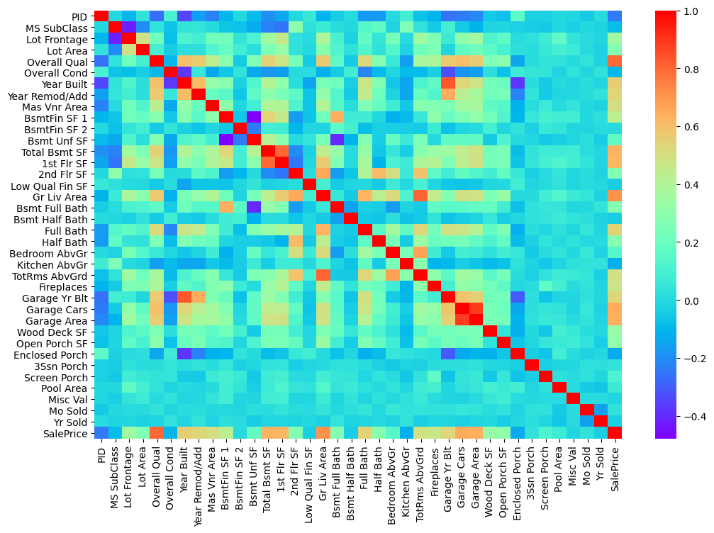

```python
# heatmap showing the correlations among all features
plt.figure(figsize=(12,8), dpi=100)
sns.heatmap(df.corr(), cmap='rainbow');
```

```python
# sort the correlation values to see which features are more correlated with sale price
df.corr()['SalePrice'].sort_values()
```

```
PID               -0.246521
Enclosed Porch    -0.128787
Kitchen AbvGr     -0.119814
Overall Cond      -0.101697
MS SubClass       -0.085092
Low Qual Fin SF   -0.037660
Bsmt Half Bath    -0.035835
Yr Sold           -0.030569
Misc Val          -0.015691
BsmtFin SF 2       0.005891
3Ssn Porch         0.032225
Mo Sold            0.035259
Pool Area          0.068403
Screen Porch       0.112151
Bedroom AbvGr      0.143913
Bsmt Unf SF        0.182855
Lot Area           0.266549
2nd Flr SF         0.269373
Bsmt Full Bath     0.276050
Half Bath          0.285056
Open Porch SF      0.312951
Wood Deck SF       0.327143
Lot Frontage       0.357318
BsmtFin SF 1       0.432914
Fireplaces         0.474558
TotRms AbvGrd      0.495474
Mas Vnr Area       0.508285
Garage Yr Blt      0.526965
Year Remod/Add     0.532974
Full Bath          0.545604
Year Built         0.558426
1st Flr SF         0.621676
Total Bsmt SF      0.632280
Garage Area        0.640401
Garage Cars        0.647877
Gr Liv Area        0.706780
Overall Qual       0.799262
SalePrice          1.000000
Name: SalePrice, dtype: float64
```

*Same correlation analysis but with a few adjustments:*

1. Show the correlation values above in a bar chart
2. Sale price is 100% correlated to itself, so we remove it from the plot
3. PID is simply the property ID number, so we remove it from the plot

**In the correlation plot below, we can see the numerical features with the highest positive (to the right) and negative (to the left) correlation to the final sale price.**

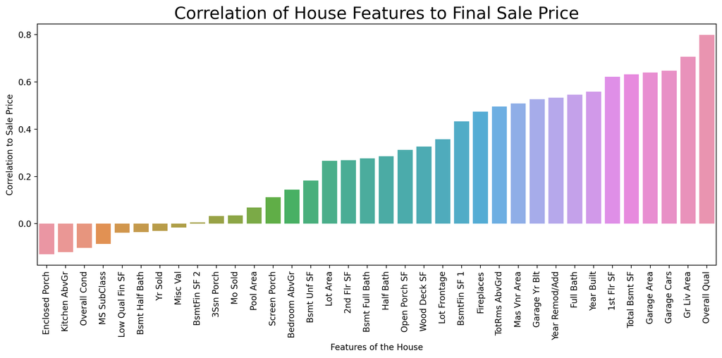

```python
# bar chart showing feature correlations to sale price
corr_sorted = df.corr()['SalePrice'].sort_values()[1:-1]
plt.figure(figsize=(12,6), dpi=200)
sns.barplot(x=corr_sorted.index, y=corr_sorted)

plt.xticks(rotation=90)
plt.xlabel('Features of the House')
plt.ylabel('Correlation to Sale Price')
plt.title('Correlation of House Features to Final Sale Price', fontsize=20)

plt.tight_layout()
plt.savefig('./house_feature_correlation.svg')
plt.savefig('./house_feature_correlation.png', dpi=300)
plt.show()
```

## Part 1: Handling Outliers

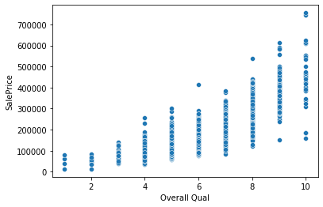

```python
# overall quality rating of the home versus the sale price
sns.scatterplot(x='Overall Qual', y='SalePrice', data=df);
```

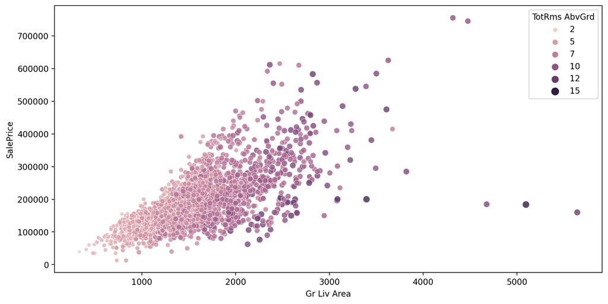

```python
# overall above-ground living area of the home versus the sale price
plt.figure(figsize=(12,6), dpi=200)
sns.scatterplot(x='Gr Liv Area', y='SalePrice', data=df,
                hue='TotRms AbvGrd',
#                 style='TotRms AbvGrd',
                size='TotRms AbvGrd',
#                 palette='deep',
                alpha=0.8);
```

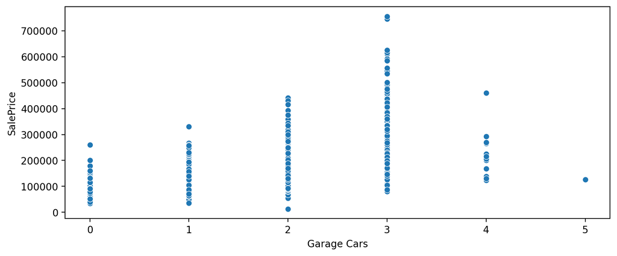

```python
# size of garage versus the sale price
plt.figure(figsize=(10,4), dpi=200)
sns.scatterplot(x='Garage Cars', y='SalePrice', data=df);
```

From the scatter plots above, we can see that there are potentially a few outliers in the original data set. For example, there are some houses with an overall rating of 9 or 10, but a sale price less than $200,000. Clearly there are other factors affecting the prices of these homes, but these few data points could be considered outliers since the general trend seen above is: the greater the rating, the greater the sale price. We can confirm this here with a box plot (below).

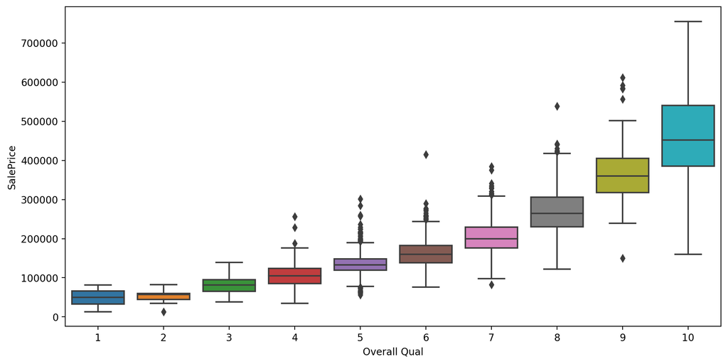

```python
plt.figure(figsize=(12,6), dpi=200)
sns.boxplot(data=df, x='Overall Qual', y='SalePrice')
plt.show()
```

```python
df[(df['Overall Qual'] > 8) & (df['SalePrice'] < 200000)]
```

|  | PID | MS SubClass | MS Zoning | Lot Frontage | Lot Area | Street | Alley | Lot Shape | Land Contour | Utilities | ... | Pool Area | Pool QC | Fence | Misc Feature | Misc Val | Mo Sold | Yr Sold | Sale Type | Sale Condition | SalePrice |
| --- | --- | --- | --- | --- | --- | --- | --- | --- | --- | --- | --- | --- | --- | --- | --- | --- | --- | --- | --- | --- | --- |
| 1182 | 533350090 | 60 | RL | NaN | 24572 | Pave | NaN | IR1 | Lvl | AllPub | ... | 0 | NaN | NaN | NaN | 0 | 6 | 2008 | WD | Family | 150000 |
| 1498 | 908154235 | 60 | RL | 313.0 | 63887 | Pave | NaN | IR3 | Bnk | AllPub | ... | 480 | Gd | NaN | NaN | 0 | 1 | 2008 | New | Partial | 160000 |
| 2180 | 908154195 | 20 | RL | 128.0 | 39290 | Pave | NaN | IR1 | Bnk | AllPub | ... | 0 | NaN | NaN | Elev | 17000 | 10 | 2007 | New | Partial | 183850 |
| 2181 | 908154205 | 60 | RL | 130.0 | 40094 | Pave | NaN | IR1 | Bnk | AllPub | ... | 0 | NaN | NaN | NaN | 0 | 10 | 2007 | New | Partial | 184750 |

4 rows × 81 columns

```python
df[(df['Gr Liv Area'] > 4000) & (df['SalePrice'] < 400000)]
```

|  | PID | MS SubClass | MS Zoning | Lot Frontage | Lot Area | Street | Alley | Lot Shape | Land Contour | Utilities | ... | Pool Area | Pool QC | Fence | Misc Feature | Misc Val | Mo Sold | Yr Sold | Sale Type | Sale Condition | SalePrice |
| --- | --- | --- | --- | --- | --- | --- | --- | --- | --- | --- | --- | --- | --- | --- | --- | --- | --- | --- | --- | --- | --- |
| 1498 | 908154235 | 60 | RL | 313.0 | 63887 | Pave | NaN | IR3 | Bnk | AllPub | ... | 480 | Gd | NaN | NaN | 0 | 1 | 2008 | New | Partial | 160000 |
| 2180 | 908154195 | 20 | RL | 128.0 | 39290 | Pave | NaN | IR1 | Bnk | AllPub | ... | 0 | NaN | NaN | Elev | 17000 | 10 | 2007 | New | Partial | 183850 |
| 2181 | 908154205 | 60 | RL | 130.0 | 40094 | Pave | NaN | IR1 | Bnk | AllPub | ... | 0 | NaN | NaN | NaN | 0 | 10 | 2007 | New | Partial | 184750 |

3 rows × 81 columns

```python
df[(df['Gr Liv Area'] > 4000) & (df['SalePrice'] < 400000)].index
```

```
Int64Index([1498, 2180, 2181], dtype='int64')
```

**We choose to drop the observations that have a living area greater than 4000 square feet and a final sale price of less than $400,000. This corresponds to 3 rows being dropped out of 2930 total rows (0.1% of the data being dropped).**

```python
drop_index = df[(df['Gr Liv Area'] > 4000) & (df['SalePrice'] < 400000)].index
```

```python
df = df.drop(drop_index, axis=0)
```

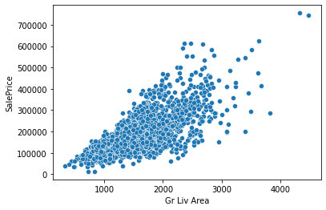

```python
sns.scatterplot(x='Gr Liv Area', y='SalePrice', data=df);
```

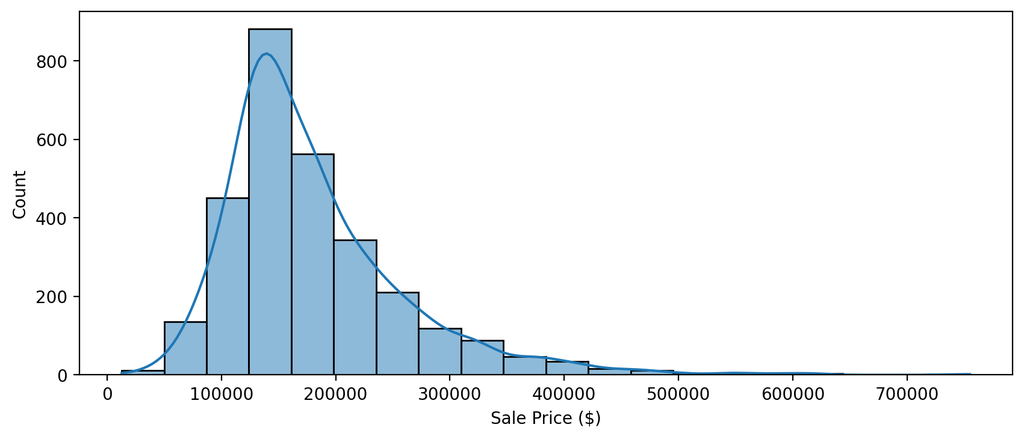

```python
price = np.array(df['SalePrice'])

plt.figure(figsize=(10,4), dpi=200)
sns.histplot(x=price, bins=20, kde=True)
plt.xlabel('Sale Price ($)')

plt.show()
```

```python
# as a quick calculation, we can also check the 25th and 75th percentiles for the house prices:
q25, q75 = np.percentile(price, [25, 75])
print(q25, q75)
```

```
129500.0 213500.0
```

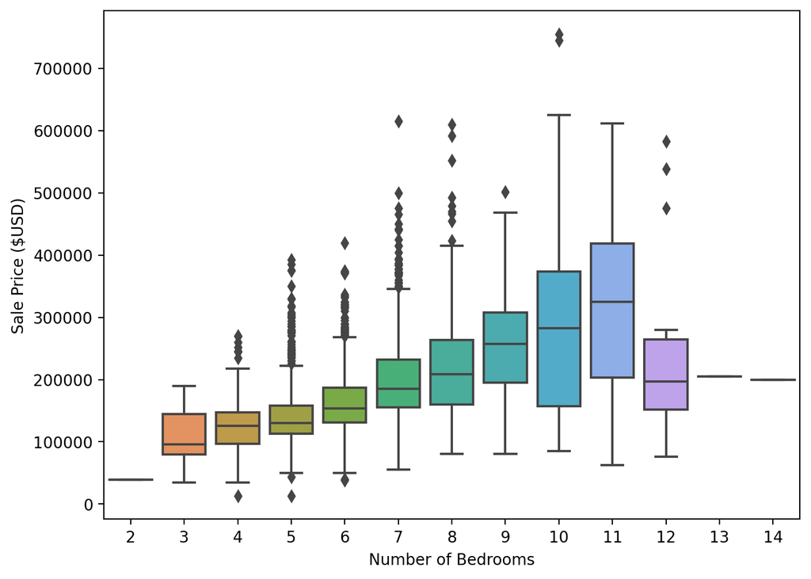

```python
plt.figure(figsize=(8,6), dpi=200)
sns.boxplot(y='SalePrice', x='TotRms AbvGrd', data=df)
plt.xlabel('Number of Bedrooms')
plt.ylabel('Sale Price ($USD)')

plt.show()
```

```python
# CHECKPOINT #1
df_drop_outliers = df.copy()
```

```python
# df = df_drop_outliers
```

## Part 2: Handling Missing Data

```python
# we can drop the PID column because it is simply the property ID value and has no predictive power
df = df.drop("PID", axis=1)
```

```python
# by checking the descriptive stats, it is clear that we have some missing values to handle
df.info()
```

```
<class 'pandas.core.frame.DataFrame'>
Int64Index: 2927 entries, 0 to 2929
Data columns (total 80 columns):
 #   Column           Non-Null Count  Dtype
---  ------           --------------  -----
 0   MS SubClass      2927 non-null   int64
 1   MS Zoning        2927 non-null   object
 2   Lot Frontage     2437 non-null   float64
 3   Lot Area         2927 non-null   int64
 4   Street           2927 non-null   object
 5   Alley            198 non-null    object
 6   Lot Shape        2927 non-null   object
 7   Land Contour     2927 non-null   object
 8   Utilities        2927 non-null   object
 9   Lot Config       2927 non-null   object
```

[output cut: 72 more lines]

In order to get a better idea of the missing values that we have in the data set, we can use a function that will compute the percentage of missing values for each feature. The percentages computed by the function are sorted and filtered such that we only focus on features (columns) where there are at least 1 missing value.

```python
# function to compute the percentage of missing values in a DataFrame object
def percent_missing (df):
    percent_nan = 100 * df.isnull().sum() / len(df)
    percent_nan = percent_nan[percent_nan > 0].sort_values()
    return percent_nan
```

```python
# compute the percent of missing values in the housing data set (range: 0% to 100%)
percent_nan = percent_missing(df)
percent_nan
```

```
Electrical         0.034165
Garage Area        0.034165
Total Bsmt SF      0.034165
Bsmt Unf SF        0.034165
BsmtFin SF 1       0.034165
BsmtFin SF 2       0.034165
Garage Cars        0.034165
Bsmt Full Bath     0.068329
Bsmt Half Bath     0.068329
Mas Vnr Area       0.785787
Mas Vnr Type       0.785787
BsmtFin Type 1     2.733174
Bsmt Qual          2.733174
Bsmt Cond          2.733174
BsmtFin Type 2     2.767339
Bsmt Exposure      2.835668
Garage Type        5.363854
Garage Finish      5.432183
Garage Qual        5.432183
Garage Cond        5.432183
Garage Yr Blt      5.432183
Lot Frontage      16.740690
Fireplace Qu      48.582166
Fence             80.457807
Alley             93.235395
Misc Feature      96.412709
Pool QC           99.590024
dtype: float64
```

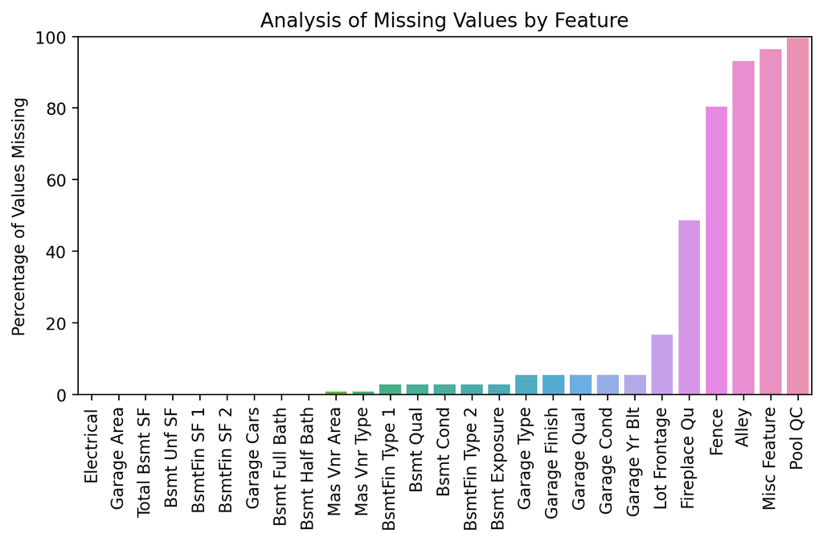

```python
# bar plot of the percentages of missing values
plt.figure(figsize=(8,4), dpi=200)
sns.barplot(x=percent_nan.index, y=percent_nan)
plt.xticks(rotation=90)
plt.ylim(0,100)
plt.title('Analysis of Missing Values by Feature')
plt.ylabel('Percentage of Values Missing')

plt.show()
```

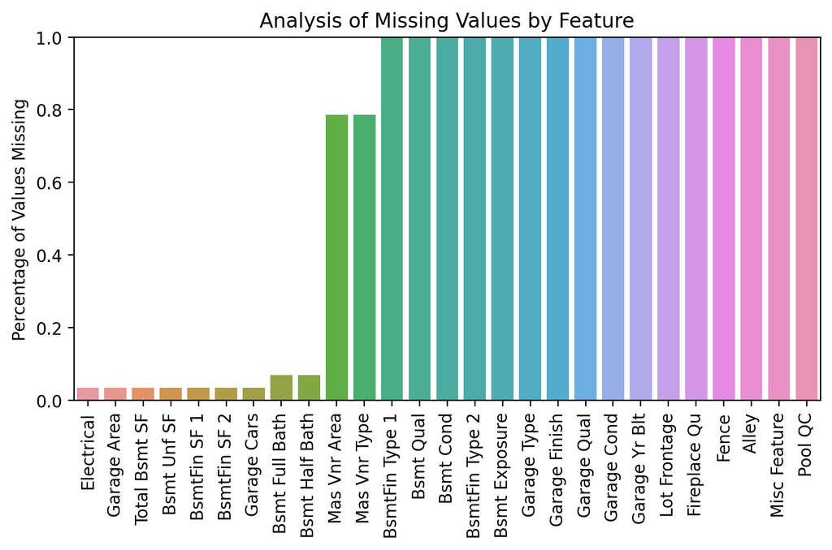

```python
# bar plot of the percentages of missing values: ZOOMED IN
plt.figure(figsize=(8,4), dpi=200)
sns.barplot(x=percent_nan.index, y=percent_nan)
plt.xticks(rotation=90)
plt.ylim(0, 1)
plt.title('Analysis of Missing Values by Feature')
plt.ylabel('Percentage of Values Missing')

plt.show()
```

```python
# features that are only missing less than 1% of the data
percent_nan[percent_nan < 1]
```

```
Electrical        0.034165
Garage Area       0.034165
Total Bsmt SF     0.034165
Bsmt Unf SF       0.034165
BsmtFin SF 1      0.034165
BsmtFin SF 2      0.034165
Garage Cars       0.034165
Bsmt Full Bath    0.068329
Bsmt Half Bath    0.068329
Mas Vnr Area      0.785787
Mas Vnr Type      0.785787
dtype: float64
```

```python
# shows that one row is missing Garage Area and there is another (different) row is missing Electrical

# df[df['Electrical'].isnull()]['Electrical']
df[df['Electrical'].isnull()]['Garage Area']
# df[df['Garage Area'].isnull()]['Electrical']
```

```
1577    400.0
Name: Garage Area, dtype: float64
```

```python
df.columns
```

```
Index(['MS SubClass', 'MS Zoning', 'Lot Frontage', 'Lot Area', 'Street',
       'Alley', 'Lot Shape', 'Land Contour', 'Utilities', 'Lot Config',
       'Land Slope', 'Neighborhood', 'Condition 1', 'Condition 2', 'Bldg Type',
       'House Style', 'Overall Qual', 'Overall Cond', 'Year Built',
       'Year Remod/Add', 'Roof Style', 'Roof Matl', 'Exterior 1st',
       'Exterior 2nd', 'Mas Vnr Type', 'Mas Vnr Area', 'Exter Qual',
       'Exter Cond', 'Foundation', 'Bsmt Qual', 'Bsmt Cond', 'Bsmt Exposure',
       'BsmtFin Type 1', 'BsmtFin SF 1', 'BsmtFin Type 2', 'BsmtFin SF 2',
       'Bsmt Unf SF', 'Total Bsmt SF', 'Heating', 'Heating QC', 'Central Air',
       'Electrical', '1st Flr SF', '2nd Flr SF', 'Low Qual Fin SF',
       'Gr Liv Area', 'Bsmt Full Bath', 'Bsmt Half Bath', 'Full Bath',
       'Half Bath', 'Bedroom AbvGr', 'Kitchen AbvGr', 'Kitchen Qual',
       'TotRms AbvGrd', 'Functional', 'Fireplaces', 'Fireplace Qu',
       'Garage Type', 'Garage Yr Blt', 'Garage Finish', 'Garage Cars',
       'Garage Area', 'Garage Qual', 'Garage Cond', 'Paved Drive',
       'Wood Deck SF', 'Open Porch SF', 'Enclosed Porch', '3Ssn Porch',
       'Screen Porch', 'Pool Area', 'Pool QC', 'Fence', 'Misc Feature',
       'Misc Val', 'Mo Sold', 'Yr Sold', 'Sale Type', 'Sale Condition',
       'SalePrice'],
      dtype='object')
```

```python
df[df['Garage Area'].isnull()][['Garage Type', 'Garage Cars', 'Garage Qual']]
```

|  | Garage Type | Garage Cars | Garage Qual |
| --- | --- | --- | --- |
| 2236 | Detchd | NaN | NaN |

```python
df['Garage Area'].describe()
```

```
count    2926.000000
mean      472.123377
std       213.939485
min         0.000000
25%       320.000000
50%       480.000000
75%       576.000000
max      1488.000000
Name: Garage Area, dtype: float64
```

```python
# there are two observations (rows) where the basement half bath is missing
df[df['Bsmt Half Bath'].isnull()]
```

|  | MS SubClass | MS Zoning | Lot Frontage | Lot Area | Street | Alley | Lot Shape | Land Contour | Utilities | Lot Config | ... | Pool Area | Pool QC | Fence | Misc Feature | Misc Val | Mo Sold | Yr Sold | Sale Type | Sale Condition | SalePrice |
| --- | --- | --- | --- | --- | --- | --- | --- | --- | --- | --- | --- | --- | --- | --- | --- | --- | --- | --- | --- | --- | --- |
| 1341 | 20 | RM | 99.0 | 5940 | Pave | NaN | IR1 | Lvl | AllPub | FR3 | ... | 0 | NaN | MnPrv | NaN | 0 | 4 | 2008 | ConLD | Abnorml | 79000 |
| 1497 | 20 | RL | 123.0 | 47007 | Pave | NaN | IR1 | Lvl | AllPub | Inside | ... | 0 | NaN | NaN | NaN | 0 | 7 | 2008 | WD | Normal | 284700 |

2 rows × 80 columns

```python
# our goal is to keep as much data as possible and not lose many observations (rows)...

# but, we will start by dropping a single row at a time since we cannot provide a reasonable estimate for these two features:
df = df.dropna(axis=0, subset=['Electrical', 'Garage Area'])
```

```python
percent_nan = percent_missing(df)
percent_nan[percent_nan < 1]
```

```
Bsmt Unf SF       0.034188
Total Bsmt SF     0.034188
BsmtFin SF 2      0.034188
BsmtFin SF 1      0.034188
Bsmt Full Bath    0.068376
Bsmt Half Bath    0.068376
Mas Vnr Type      0.786325
Mas Vnr Area      0.786325
dtype: float64
```

By looking at the percent of missing values above (where the percent missing is less than 1%), we can see that many of these features are related to basements: the smallest six values in the cell above are all associated with basements ("Bsmt"). It seems that these missing values are related to the fact that some homes do not have basements. We can use this knowledge to fill in such missing values with zero (e.g., for features like total basement area: if there is no basement, then the area can logically be set to zero).

```python
df[df['Bsmt Half Bath'].isnull()]
```

|  | MS SubClass | MS Zoning | Lot Frontage | Lot Area | Street | Alley | Lot Shape | Land Contour | Utilities | Lot Config | ... | Pool Area | Pool QC | Fence | Misc Feature | Misc Val | Mo Sold | Yr Sold | Sale Type | Sale Condition | SalePrice |
| --- | --- | --- | --- | --- | --- | --- | --- | --- | --- | --- | --- | --- | --- | --- | --- | --- | --- | --- | --- | --- | --- |
| 1341 | 20 | RM | 99.0 | 5940 | Pave | NaN | IR1 | Lvl | AllPub | FR3 | ... | 0 | NaN | MnPrv | NaN | 0 | 4 | 2008 | ConLD | Abnorml | 79000 |
| 1497 | 20 | RL | 123.0 | 47007 | Pave | NaN | IR1 | Lvl | AllPub | Inside | ... | 0 | NaN | NaN | NaN | 0 | 7 | 2008 | WD | Normal | 284700 |

2 rows × 80 columns

```python
df[df['Bsmt Full Bath'].isnull()]['Total Bsmt SF']
```

```
1341    NaN
1497    0.0
Name: Total Bsmt SF, dtype: float64
```

```python
df[df['Bsmt Cond'].isnull()]['Total Bsmt SF'].isnull().sum()
```

```
1
```

```python
df[df['Bsmt Unf SF'].isnull()]
```

|  | MS SubClass | MS Zoning | Lot Frontage | Lot Area | Street | Alley | Lot Shape | Land Contour | Utilities | Lot Config | ... | Pool Area | Pool QC | Fence | Misc Feature | Misc Val | Mo Sold | Yr Sold | Sale Type | Sale Condition | SalePrice |
| --- | --- | --- | --- | --- | --- | --- | --- | --- | --- | --- | --- | --- | --- | --- | --- | --- | --- | --- | --- | --- | --- |
| 1341 | 20 | RM | 99.0 | 5940 | Pave | NaN | IR1 | Lvl | AllPub | FR3 | ... | 0 | NaN | MnPrv | NaN | 0 | 4 | 2008 | ConLD | Abnorml | 79000 |

1 rows × 80 columns

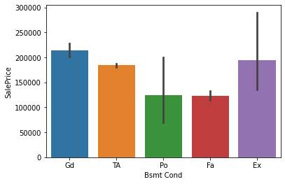

```python
sns.barplot(data=df, y='SalePrice', x='Bsmt Cond');
```

```python
bsmt_cat_cols = ['Bsmt Qual', 'Bsmt Cond', 'Bsmt Exposure', 'BsmtFin Type 1', 'BsmtFin Type 2']
df['Bsmt Qual'].unique()
```

```
array(['TA', 'Gd', 'Ex', nan, 'Fa', 'Po'], dtype=object)
```

```python
# BASEMENT NUMERIC COLUMNS --> fillna 0
bsmt_num_cols = ['BsmtFin SF 1', 'BsmtFin SF 2', 'Bsmt Unf SF', 'Total Bsmt SF', 'Bsmt Full Bath', 'Bsmt Half Bath']
df[bsmt_num_cols] = df[bsmt_num_cols].fillna(0)

# BASEMENT STRING COLUMNS
bsmt_cat_cols = ['Bsmt Qual', 'Bsmt Cond', 'Bsmt Exposure', 'BsmtFin Type 1', 'BsmtFin Type 2']
df[bsmt_cat_cols] = df[bsmt_cat_cols].fillna('None')
```

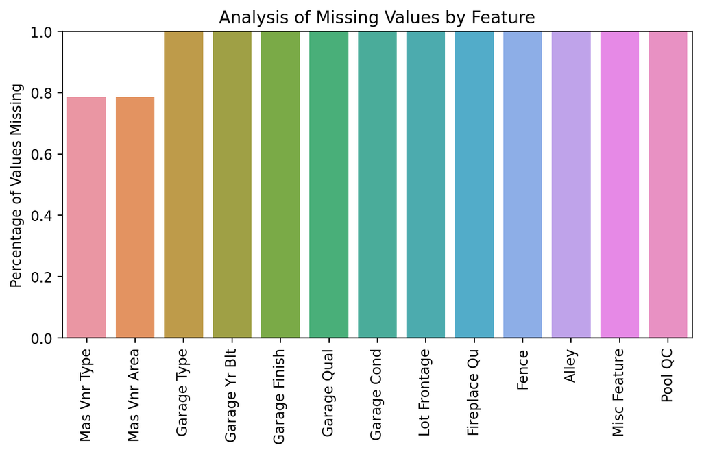

```python
# bar plot of the percentages of missing values: ZOOMED IN

# UPDATE MISSING VALUES
percent_nan = percent_missing(df)

plt.figure(figsize=(8,4), dpi=200)
sns.barplot(x=percent_nan.index, y=percent_nan)
plt.xticks(rotation=90)
plt.ylim(0, 1)
plt.title('Analysis of Missing Values by Feature')
plt.ylabel('Percentage of Values Missing')

plt.show()
```

```python
# we do a similar data cleaning here for these masonry features
# (we assume a missing value for these features means that the home does not have them)
df['Mas Vnr Type'] = df['Mas Vnr Type'].fillna("None")
df['Mas Vnr Area'] = df['Mas Vnr Area'].fillna(0)
```

```python
# bar plot of the percentages of missing values
def plot_missing_values(data=df, y_min=0, y_max=100):

    # UPDATE MISSING VALUES
    percent_nan = percent_missing(data)

    plt.figure(figsize=(8,4), dpi=200)
    sns.barplot(x=percent_nan.index, y=percent_nan)
    plt.xticks(rotation=90)
    plt.ylim(y_min, y_max)
    plt.title('Analysis of Missing Values by Feature')
    plt.ylabel('Percentage of Values Missing')

    plt.show()
```

### Fixing Data in Columns (Features)

Two approaches to consider:

- Fill in missing values
- Drop the feature column altogether

```python
# For the garage features, it seems that the missing values correspond to houses that do not have garages.
# Therefore, we can replace the missing categorical data related to garages with the value "None"
# to indicate that the home does not have a garage.
garage_cat_cols = ['Garage Type', 'Garage Finish', 'Garage Qual', 'Garage Cond']
df[garage_cat_cols] = df[garage_cat_cols].fillna('None')
```

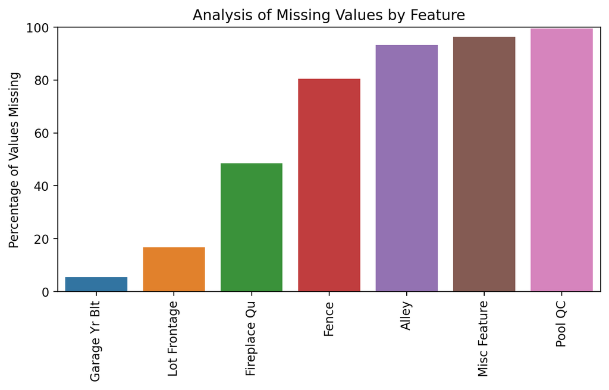

```python
plot_missing_values(data=df)
```

```python
# What should we do with the Garage Year Built?

# We can use Year = 0
# OR use the average Garage Year Built from the other data
df['Garage Yr Blt'] = df['Garage Yr Blt'].fillna(0)
```

```python
# Since we have such a large percentage of missing values in the following features:
#   Pool QC      ~100%
#   Misc Feature  >95%
#   Alley         >90%
#   Fence         >80%
#... we decide to DROP these features from the data set here
df = df.drop(['Pool QC', 'Misc Feature', 'Alley', 'Fence'], axis=1)
```

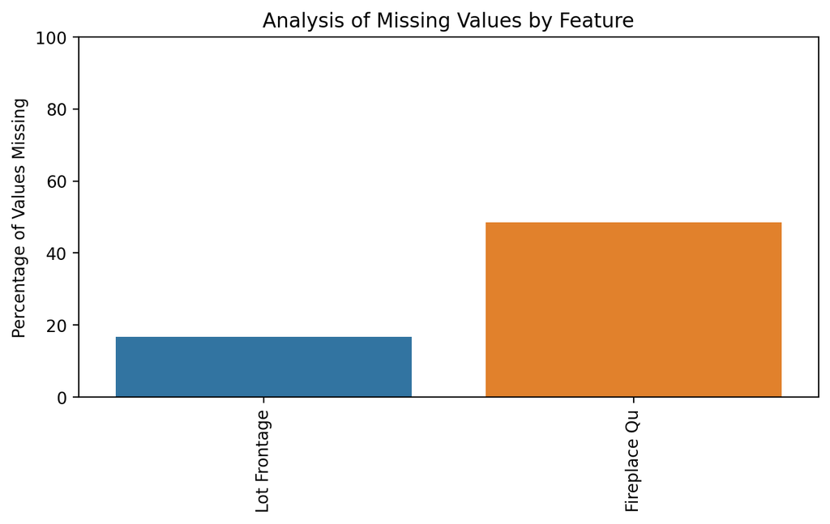

```python
plot_missing_values(df)
```

```python
df['Fireplace Qu'].value_counts()
```

```
Gd    741
TA    600
Fa     75
Po     46
Ex     43
Name: Fireplace Qu, dtype: int64
```

```python
# the null values for fireplace must correspond to "No Fireplace" (as seen in the description of the data set earlier)
df['Fireplace Qu'] = df['Fireplace Qu'].fillna('None')
```

**The final feature with missing values now is the "lot frontage" feature.**

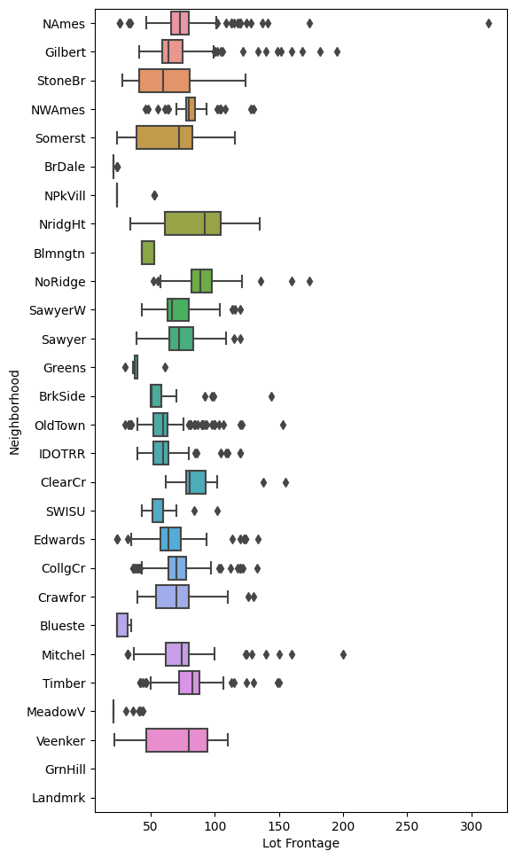

```python
# here we can see the lot frontage values according to neighborhood
plt.figure(figsize=(6,12), dpi=100)
sns.boxplot(x='Lot Frontage', y='Neighborhood', data=df, orient='h');
```

```python
# mean lot frontage by neighborhood
df.groupby('Neighborhood')['Lot Frontage'].mean()
```

```
Neighborhood
Blmngtn    46.900000
Blueste    27.300000
BrDale     21.500000
BrkSide    55.789474
ClearCr    88.150000
CollgCr    71.336364
Crawfor    69.951807
Edwards    64.794286
Gilbert    74.207207
Greens     41.000000
GrnHill          NaN
IDOTRR     62.383721
Landmrk          NaN
MeadowV    25.606061
Mitchel    75.144444
NAmes      75.210667
NPkVill    28.142857
NWAmes     81.517647
NoRidge    91.629630
NridgHt    84.184049
OldTown    61.777293
SWISU      59.068182
Sawyer     74.551020
SawyerW    70.669811
Somerst    64.549383
StoneBr    62.173913
Timber     81.303571
Veenker    72.000000
Name: Lot Frontage, dtype: float64
```

**For the missing values in the lot frontage area, we will use the average frontage area for homes in the same neighborhood.**

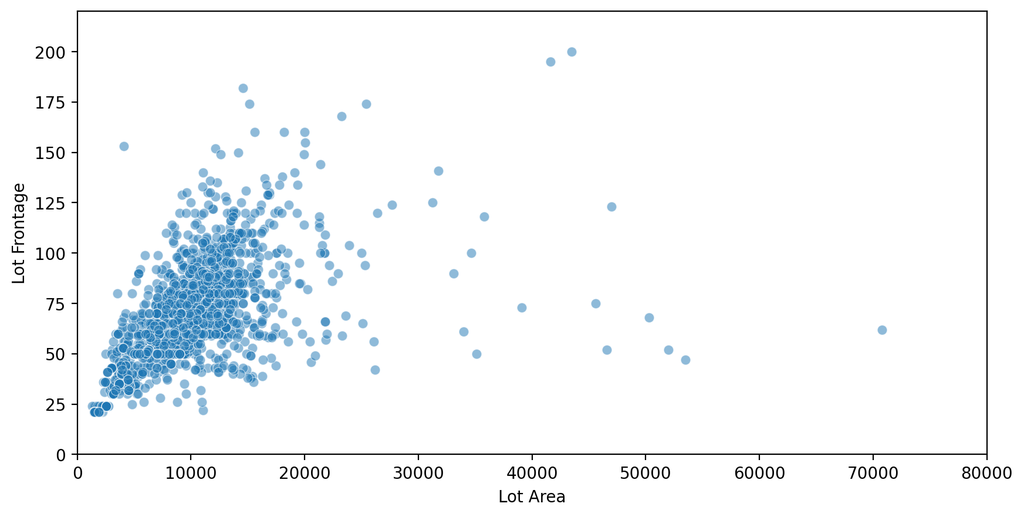

```python
plt.figure(figsize=(10,5), dpi=200)
sns.scatterplot(data=df, x='Lot Area', y='Lot Frontage', alpha=0.5)
plt.xlim(0, 80000)
plt.ylim(0, 220)
plt.show()
```

```python
df_temp = df[df['Lot Frontage'].notnull()]
df_temp.corr()['Lot Frontage'].sort_values()
```

```
MS SubClass       -0.430521
Overall Cond      -0.072866
Bsmt Half Bath    -0.028655
Yr Sold           -0.007396
Low Qual Fin SF    0.006049
Kitchen AbvGr      0.006890
Misc Val           0.014022
Mo Sold            0.016471
Enclosed Porch     0.016562
2nd Flr SF         0.021647
3Ssn Porch         0.029928
Half Bath          0.034289
BsmtFin SF 2       0.048845
Screen Porch       0.080470
Year Remod/Add     0.087098
Bsmt Full Bath     0.094725
Garage Yr Blt      0.103244
Wood Deck SF       0.114204
Year Built         0.116581
Bsmt Unf SF        0.118046
Pool Area          0.125000
Open Porch SF      0.141202
BsmtFin SF 1       0.165814
Full Bath          0.182655
Overall Qual       0.200698
Mas Vnr Area       0.201185
Fireplaces         0.244824
Bedroom AbvGr      0.246874
Garage Cars        0.312195
Total Bsmt SF      0.312418
TotRms AbvGrd      0.341440
Garage Area        0.345994
Gr Liv Area        0.355336
SalePrice          0.367518
1st Flr SF         0.432625
Lot Area           0.468168
Lot Frontage       1.000000
Name: Lot Frontage, dtype: float64
```

```python
# For missing lot frontage values, we will fill in the null values with the mean lot frontage for that neighborhood.

# use pandas.DataFrame.transform: combine groupby and apply methods
df['Lot Frontage'] = df.groupby('Neighborhood')['Lot Frontage'].transform(lambda val: val.fillna(val.mean()))
```

```python
df.isnull().sum()
```

```
MS SubClass       0
MS Zoning         0
Lot Frontage      3
Lot Area          0
Street            0
                 ..
Mo Sold           0
Yr Sold           0
Sale Type         0
Sale Condition    0
SalePrice         0
Length: 76, dtype: int64
```

```python
# There are 3 remaining values missing for the lot frontage:
# So we will fill these with the mean lot frontage value for the full data set...

mean_lot_frontage = df['Lot Frontage'].mean()
df['Lot Frontage'] = df['Lot Frontage'].fillna(mean_lot_frontage)
```

```python
percent_missing(df)
```

```
Series([], dtype: float64)
```

```python
df.reset_index(inplace=True)
```

```python
df.columns

# note: if there is an extra column like 'level_0' or 'index' inserted here, you can drop it with the next cell.
```

```
Index(['index', 'MS SubClass', 'MS Zoning', 'Lot Frontage', 'Lot Area',
       'Street', 'Lot Shape', 'Land Contour', 'Utilities', 'Lot Config',
       'Land Slope', 'Neighborhood', 'Condition 1', 'Condition 2', 'Bldg Type',
       'House Style', 'Overall Qual', 'Overall Cond', 'Year Built',
       'Year Remod/Add', 'Roof Style', 'Roof Matl', 'Exterior 1st',
       'Exterior 2nd', 'Mas Vnr Type', 'Mas Vnr Area', 'Exter Qual',
       'Exter Cond', 'Foundation', 'Bsmt Qual', 'Bsmt Cond', 'Bsmt Exposure',
       'BsmtFin Type 1', 'BsmtFin SF 1', 'BsmtFin Type 2', 'BsmtFin SF 2',
       'Bsmt Unf SF', 'Total Bsmt SF', 'Heating', 'Heating QC', 'Central Air',
       'Electrical', '1st Flr SF', '2nd Flr SF', 'Low Qual Fin SF',
       'Gr Liv Area', 'Bsmt Full Bath', 'Bsmt Half Bath', 'Full Bath',
       'Half Bath', 'Bedroom AbvGr', 'Kitchen AbvGr', 'Kitchen Qual',
       'TotRms AbvGrd', 'Functional', 'Fireplaces', 'Fireplace Qu',
       'Garage Type', 'Garage Yr Blt', 'Garage Finish', 'Garage Cars',
       'Garage Area', 'Garage Qual', 'Garage Cond', 'Paved Drive',
       'Wood Deck SF', 'Open Porch SF', 'Enclosed Porch', '3Ssn Porch',
       'Screen Porch', 'Pool Area', 'Misc Val', 'Mo Sold', 'Yr Sold',
       'Sale Type', 'Sale Condition', 'SalePrice'],
      dtype='object')
```

```python
# only run this if necessary ...

# drop_these_cols = ['level_0', 'index']
drop_these_cols = ['index']

df.drop(drop_these_cols, axis=1, inplace=True)
```

At this point, we have now handled all the missing values in the Ames housing data set.

Original Data: 2930 rows with 81 columns

**NEW Data with No Missing Values: 2925 rows with 76 columns**

```python
df.info()
```

```
<class 'pandas.core.frame.DataFrame'>
RangeIndex: 2925 entries, 0 to 2924
Data columns (total 76 columns):
 #   Column           Non-Null Count  Dtype
---  ------           --------------  -----
 0   MS SubClass      2925 non-null   int64
 1   MS Zoning        2925 non-null   object
 2   Lot Frontage     2925 non-null   float64
 3   Lot Area         2925 non-null   int64
 4   Street           2925 non-null   object
 5   Lot Shape        2925 non-null   object
 6   Land Contour     2925 non-null   object
 7   Utilities        2925 non-null   object
 8   Lot Config       2925 non-null   object
 9   Land Slope       2925 non-null   object
```

[output cut: 68 more lines]

```python
# CHECKPOINT #2
df_clean = df.copy()
```

## Part 3: Handling Categorical Data

```python
# After reviewing our data set, we see that the MS SubClass feature is entered as "numeric" data,
# but in reality, these numbers do not have a linear relationship: they act as categories.
df['MS SubClass'] = df['MS SubClass'].apply(str)
```

```python
# split our data into categorical and numerical
df_categorical = df.select_dtypes(include='object')
df_numerical = df.select_dtypes(exclude='object')
```

```python
# create dummy variables from the categorical data only
df_dummies = pd.get_dummies(df_categorical, drop_first=True)
df_dummies
```

|  | MS SubClass_150 | MS SubClass_160 | MS SubClass_180 | MS SubClass_190 | MS SubClass_20 | MS SubClass_30 | MS SubClass_40 | MS SubClass_45 | MS SubClass_50 | MS SubClass_60 | ... | Sale Type_ConLw | Sale Type_New | Sale Type_Oth | Sale Type_VWD | Sale Type_WD | Sale Condition_AdjLand | Sale Condition_Alloca | Sale Condition_Family | Sale Condition_Normal | Sale Condition_Partial |
| --- | --- | --- | --- | --- | --- | --- | --- | --- | --- | --- | --- | --- | --- | --- | --- | --- | --- | --- | --- | --- | --- |
| 0 | 0 | 0 | 0 | 0 | 1 | 0 | 0 | 0 | 0 | 0 | ... | 0 | 0 | 0 | 0 | 1 | 0 | 0 | 0 | 1 | 0 |
| 1 | 0 | 0 | 0 | 0 | 1 | 0 | 0 | 0 | 0 | 0 | ... | 0 | 0 | 0 | 0 | 1 | 0 | 0 | 0 | 1 | 0 |
| 2 | 0 | 0 | 0 | 0 | 1 | 0 | 0 | 0 | 0 | 0 | ... | 0 | 0 | 0 | 0 | 1 | 0 | 0 | 0 | 1 | 0 |
| 3 | 0 | 0 | 0 | 0 | 1 | 0 | 0 | 0 | 0 | 0 | ... | 0 | 0 | 0 | 0 | 1 | 0 | 0 | 0 | 1 | 0 |
| 4 | 0 | 0 | 0 | 0 | 0 | 0 | 0 | 0 | 0 | 1 | ... | 0 | 0 | 0 | 0 | 1 | 0 | 0 | 0 | 1 | 0 |
| ... | ... | ... | ... | ... | ... | ... | ... | ... | ... | ... | ... | ... | ... | ... | ... | ... | ... | ... | ... | ... | ... |
| 2920 | 0 | 0 | 0 | 0 | 0 | 0 | 0 | 0 | 0 | 0 | ... | 0 | 0 | 0 | 0 | 1 | 0 | 0 | 0 | 1 | 0 |
| 2921 | 0 | 0 | 0 | 0 | 1 | 0 | 0 | 0 | 0 | 0 | ... | 0 | 0 | 0 | 0 | 1 | 0 | 0 | 0 | 1 | 0 |
| 2922 | 0 | 0 | 0 | 0 | 0 | 0 | 0 | 0 | 0 | 0 | ... | 0 | 0 | 0 | 0 | 1 | 0 | 0 | 0 | 1 | 0 |
| 2923 | 0 | 0 | 0 | 0 | 1 | 0 | 0 | 0 | 0 | 0 | ... | 0 | 0 | 0 | 0 | 1 | 0 | 0 | 0 | 1 | 0 |
| 2924 | 0 | 0 | 0 | 0 | 0 | 0 | 0 | 0 | 0 | 1 | ... | 0 | 0 | 0 | 0 | 1 | 0 | 0 | 0 | 1 | 0 |

2925 rows × 238 columns

```python
df_final = pd.concat([df_numerical, df_dummies], axis=1)
df_final
```

|  | Lot Frontage | Lot Area | Overall Qual | Overall Cond | Year Built | Year Remod/Add | Mas Vnr Area | BsmtFin SF 1 | BsmtFin SF 2 | Bsmt Unf SF | ... | Sale Type_ConLw | Sale Type_New | Sale Type_Oth | Sale Type_VWD | Sale Type_WD | Sale Condition_AdjLand | Sale Condition_Alloca | Sale Condition_Family | Sale Condition_Normal | Sale Condition_Partial |
| --- | --- | --- | --- | --- | --- | --- | --- | --- | --- | --- | --- | --- | --- | --- | --- | --- | --- | --- | --- | --- | --- |
| 0 | 141.000000 | 31770 | 6 | 5 | 1960 | 1960 | 112.0 | 639.0 | 0.0 | 441.0 | ... | 0 | 0 | 0 | 0 | 1 | 0 | 0 | 0 | 1 | 0 |
| 1 | 80.000000 | 11622 | 5 | 6 | 1961 | 1961 | 0.0 | 468.0 | 144.0 | 270.0 | ... | 0 | 0 | 0 | 0 | 1 | 0 | 0 | 0 | 1 | 0 |
| 2 | 81.000000 | 14267 | 6 | 6 | 1958 | 1958 | 108.0 | 923.0 | 0.0 | 406.0 | ... | 0 | 0 | 0 | 0 | 1 | 0 | 0 | 0 | 1 | 0 |
| 3 | 93.000000 | 11160 | 7 | 5 | 1968 | 1968 | 0.0 | 1065.0 | 0.0 | 1045.0 | ... | 0 | 0 | 0 | 0 | 1 | 0 | 0 | 0 | 1 | 0 |
| 4 | 74.000000 | 13830 | 5 | 5 | 1997 | 1998 | 0.0 | 791.0 | 0.0 | 137.0 | ... | 0 | 0 | 0 | 0 | 1 | 0 | 0 | 0 | 1 | 0 |
| ... | ... | ... | ... | ... | ... | ... | ... | ... | ... | ... | ... | ... | ... | ... | ... | ... | ... | ... | ... | ... | ... |
| 2920 | 37.000000 | 7937 | 6 | 6 | 1984 | 1984 | 0.0 | 819.0 | 0.0 | 184.0 | ... | 0 | 0 | 0 | 0 | 1 | 0 | 0 | 0 | 1 | 0 |
| 2921 | 75.144444 | 8885 | 5 | 5 | 1983 | 1983 | 0.0 | 301.0 | 324.0 | 239.0 | ... | 0 | 0 | 0 | 0 | 1 | 0 | 0 | 0 | 1 | 0 |
| 2922 | 62.000000 | 10441 | 5 | 5 | 1992 | 1992 | 0.0 | 337.0 | 0.0 | 575.0 | ... | 0 | 0 | 0 | 0 | 1 | 0 | 0 | 0 | 1 | 0 |
| 2923 | 77.000000 | 10010 | 5 | 5 | 1974 | 1975 | 0.0 | 1071.0 | 123.0 | 195.0 | ... | 0 | 0 | 0 | 0 | 1 | 0 | 0 | 0 | 1 | 0 |
| 2924 | 74.000000 | 9627 | 7 | 5 | 1993 | 1994 | 94.0 | 758.0 | 0.0 | 238.0 | ... | 0 | 0 | 0 | 0 | 1 | 0 | 0 | 0 | 1 | 0 |

2925 rows × 274 columns

```python
# We can now check which features have the highest correlation with the sale price
# (including categorical data as dummy variables)

# df_final.corr()['SalePrice'].sort_values()
np.abs(df_final.corr()['SalePrice']).nlargest(10)
```

```
SalePrice        1.000000
Overall Qual     0.802637
Gr Liv Area      0.727279
Total Bsmt SF    0.660983
Garage Cars      0.648488
1st Flr SF       0.645635
Garage Area      0.644368
Exter Qual_TA    0.591459
Year Built       0.559165
Full Bath        0.546645
Name: SalePrice, dtype: float64
```

```python
# SAVE FINAL DATAFRAME AS OUTPUT
df_final.to_csv('./data_processed/Ames_Housing_Data_Clean_Dummies.csv', index=False)
```